# **Problem Statement**

## **Business Context**

Workplace safety in hazardous environments like construction sites and industrial plants is crucial to prevent accidents and injuries. One of the most important safety measures is ensuring workers wear safety helmets, which protect against head injuries from falling objects and machinery. Non-compliance with helmet regulations increases the risk of serious injuries or fatalities, making effective monitoring essential, especially in large-scale operations where manual oversight is prone to errors and inefficiency.

To overcome these challenges, SafeGuard Corp plans to develop an automated image analysis system capable of detecting whether workers are wearing safety helmets. This system will improve safety enforcement, ensuring compliance and reducing the risk of head injuries. By automating helmet monitoring, SafeGuard aims to enhance efficiency, scalability, and accuracy, ultimately fostering a safer work environment while minimizing human error in safety oversight.

## **Objective**

As a data scientist at SafeGuard Corp, you are tasked with developing an image classification model that classifies images into one of two categories:

- **With Helmet:** Workers wearing safety helmets.
- **Without Helmet:** Workers not wearing safety helmets.

## **Data Description**

The dataset consists of **4125 images**, divided into two categories:

- **With Helmet:** 3161 images showing workers wearing helmets.
- **Without Helmet:** 964 images showing workers not wearing helmets.

**Dataset Characteristics:**

- **Variations in Conditions:** Images include diverse environments such as construction sites, factories, and industrial settings, with variations in lighting, angles, and worker postures to simulate real-world conditions.
- **Worker Activities:** Workers are depicted in different actions such as standing, using tools, or moving, ensuring robust model learning for various scenarios.

# **Installing and Importing the Necessary Libraries**

```python
!pip install tensorflow[and-cuda] scikit-learn==1.6.1 opencv-python==4.12.0.88 seaborn==0.13.2 matplotlib==3.10.0 numpy==2.0.2 pandas==2.2.2 -q
```

[output not shown]

**Note:**

- After running the above cell, kindly restart the notebook kernel (for Jupyter Notebook) or runtime (for Google Colab) and run all cells sequentially from the next cell.
- On executing the above line of code, you might see a warning regarding package dependencies. This error message can be ignored as the above code ensures that all necessary libraries and their dependencies are maintained to successfully execute the code in this notebook.

```python
import os
import random
import numpy as np                                                                               # Importing numpy for Matrix Operations
import pandas as pd
import seaborn as sns
import matplotlib.image as mpimg                                                                              # Importing pandas to read CSV files
import matplotlib.pyplot as plt                                                                  # Importting matplotlib for Plotting and visualizing images
import math                                                                                      # Importing math module to perform mathematical operations
import cv2


# Tensorflow modules
import keras
import tensorflow as tf
from tensorflow.keras.preprocessing.image import ImageDataGenerator                              # Importing the ImageDataGenerator for data augmentation
from tensorflow.keras.models import Sequential                                                   # Importing the sequential module to define a sequential model
from tensorflow.keras.layers import Dense,Dropout,Flatten,Conv2D,MaxPooling2D,BatchNormalization # Defining all the layers to build our CNN Model
from tensorflow.keras.optimizers import Adam,SGD                                                 # Importing the optimizers which can be used in our model
from sklearn import preprocessing                                                                # Importing the preprocessing module to preprocess the data
from sklearn.model_selection import train_test_split                                             # Importing train_test_split function to split the data into train and test
from sklearn.metrics import confusion_matrix
from tensorflow.keras.models import Model
from keras.applications.vgg16 import VGG16                                               # Importing confusion_matrix to plot the confusion matrix

# Display images using OpenCV
from google.colab.patches import cv2_imshow

#Imports functions for evaluating the performance of machine learning models
from sklearn.metrics import confusion_matrix, f1_score,accuracy_score, recall_score, precision_score, classification_report
from sklearn.metrics import mean_squared_error as mse                                                 # Importing cv2_imshow from google.patches to display images

# Ignore warnings
import warnings
warnings.filterwarnings('ignore')
```

```python
print("Num GPUs Available:", len(tf.config.list_physical_devices('GPU')))
print(tf.__version__)
```

```
Num GPUs Available: 1
2.19.0
```

```python
# 1. Set Python random seed
random.seed(812)

# 2. Set NumPy random seed
np.random.seed(812)

# 3. Set TensorFlow seed (covers Keras + backend)
tf.keras.utils.set_random_seed(812)

# 4. Enable deterministic GPU ops (if using GPU)
tf.config.experimental.enable_op_determinism()
```

# **Data Overview**

## Loading the data

```python
#Uncomment and run the following code in case Google Colab is being used
from google.colab import drive
drive.mount('/content/drive')
```

```python
images = np.load('/content/drive/MyDrive/Colab Notebooks/CNN/images.npy') #Complete the code to load the images

labels = pd.read_csv('/content/drive/MyDrive/Colab Notebooks/CNN/labels.csv') #Complete the code to load the labels
```

```python
print(images.shape) #Complete the code to print the shape of the images
print(labels.shape)
```

```
(4125, 200, 200, 3)
(4125, 1)
```

```python
images_decreased = []
height = 64
width = 64
dimensions = (width, height)
for i in range(len(images)):
  images_decreased.append(cv2.resize(images[i], dimensions, interpolation=cv2.INTER_LINEAR))
```

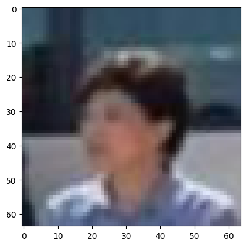

```python
plt.imshow(images_decreased[3]);
```

**Visualizing using Gaussian Blur**

```python
# Applying Gaussian Blur to denoise the images
images_gb=[]
for i in range(len(images_decreased)):
    images_gb.append(cv2.GaussianBlur(images_decreased[i], ksize =(3,3),sigmaX =  0))
```

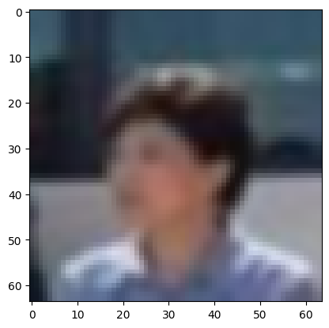

```python
plt.imshow(images_gb[3]);
```

# **Exploratory Data Analysis**

### Plot random images from each of the classes and print their corresponding labels.

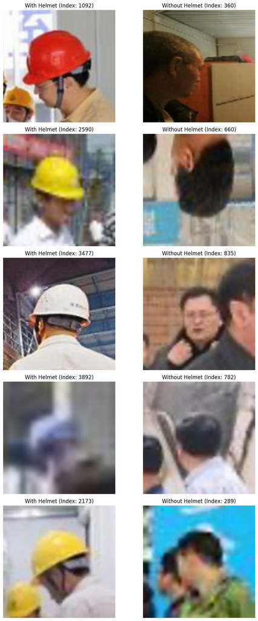

```python
# Get indices for 'With Helmet' (label 1) and 'Without Helmet' (label 0)
helmet_indices = labels[labels.iloc[:, 0] == 1].index.tolist()
no_helmet_indices = labels[labels.iloc[:, 0] == 0].index.tolist()

# Select 5 random indices from each class
num_samples_to_plot = 5
random_helmet_idxs = random.sample(helmet_indices, num_samples_to_plot)
random_no_helmet_idxs = random.sample(no_helmet_indices, num_samples_to_plot)

fig, axes = plt.subplots(num_samples_to_plot, 2, figsize=(10, 4 * num_samples_to_plot))

for i in range(num_samples_to_plot):
    # Plot 'With Helmet' images
    axes[i][0].imshow(images[random_helmet_idxs[i]])
    axes[i][0].set_title(f"With Helmet (Index: {random_helmet_idxs[i]})")
    axes[i][0].axis("off")

    # Plot 'Without Helmet' images
    axes[i][1].imshow(images[random_no_helmet_idxs[i]])
    axes[i][1].set_title(f"Without Helmet (Index: {random_no_helmet_idxs[i]})")
    axes[i][1].axis("off")

plt.tight_layout()
plt.show()
```

## Checking for class imbalance

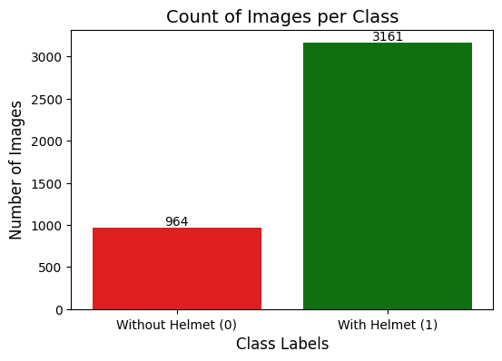

```python
# Create a count plot
plt.figure(figsize=(6, 4))
ax = sns.countplot(x=labels.iloc[:, 0], palette=['red', 'green'])

# Add exact counts on top of bars
for p in ax.patches:
    ax.annotate(f'{int(p.get_height())}', (p.get_x() + p.get_width() / 2, p.get_height()),
                ha='center', va='bottom', fontsize=10, )

# Add labels
plt.xlabel("Class Labels", fontsize=12)
plt.ylabel("Number of Images", fontsize=12)
plt.title("Count of Images per Class", fontsize=14)
plt.xticks(ticks=[0, 1], labels=["Without Helmet (0)", "With Helmet (1)"])  # Rename x-axis labels

# Show plot
plt.show()
```

# **Data Preprocessing**

### Splitting the dataset

- For a dataset of 4125 records, common split is 70% for trainings, 15% for validation and 15% for testing.
- We are using the train_test_split() function from scikit-learn. Here, we split the dataset into three parts, train,test and validation.

```python
from sklearn.model_selection import train_test_split
X_train, X_temp, y_train, y_temp = train_test_split(np.array(images_decreased),labels , test_size=0.3, random_state=42,stratify=labels) #Complete the code to define the test_size
X_val, X_test, y_val, y_test = train_test_split(X_temp,y_temp , test_size=0.5, random_state=42,stratify=y_temp) #Complete the code to define the test_size
```

```python
print(X_train.shape,y_train.shape)
print(X_val.shape,y_val.shape)
print(X_test.shape,y_test.shape)
```

```
(2887, 64, 64, 3) (2887, 1)
(619, 64, 64, 3) (619, 1)
(619, 64, 64, 3) (619, 1)
```

Encoding the target labels Convert labels from names to one hot vectors

```python
# Convert labels from names to one hot vectors.
# Labelbinarizer works similar to onehotencoder
from sklearn.preprocessing import LabelBinarizer
enc = LabelBinarizer()
y_train_encoded = enc.fit_transform(y_train)
y_val_encoded=enc.transform(y_val)
y_test_encoded=enc.transform(y_test)
```

### Data Normalization

Since the image pixel values range from 0-255, our method of normalization here will be scaling - we shall divide all the pixel values by 255 to standardize the images to have values between 0-1.

```python
# Normalizing the image pixels
X_train_normalized = X_train.astype('float32')/255.0
X_val_normalized = X_val.astype('float32')/255.0
X_test_normalized = X_test.astype('float32')/255.0
```

# **Model Building**

## Model Evaluation Criterion

## Utility Functions

```python
# defining a function to compute different metrics to check performance of a classification model built using statsmodels
def model_performance_classification(model, predictors, target):
    """
    Function to compute different metrics to check classification model performance

    model: classifier
    predictors: independent variables
    target: dependent variable
    """

    # checking which probabilities are greater than threshold
    pred = model.predict(predictors).reshape(-1)>0.5

    # Check if target is a pandas DataFrame/Series, if so convert to numpy array
    if isinstance(target, pd.DataFrame) or isinstance(target, pd.Series):
        target = target.to_numpy().reshape(-1)
    else: # Assume it's already a numpy array
        target = target.reshape(-1)


    acc = accuracy_score(target, pred)  # to compute Accuracy
    recall = recall_score(target, pred, average='micro')  # to compute Recall
    precision = precision_score(target, pred, average='micro')  # to compute Precision
    f1 = f1_score(target, pred, average='micro')  # to compute F1-score

    # creating a dataframe of metrics
    df_perf = pd.DataFrame({"Accuracy": acc, "Recall": recall, "Precision": precision, "F1 Score": f1,},index=[0],)

    return df_perf
```

```python
def plot_confusion_matrix(model,predictors,target,ml=False):
    """
    Function to plot the confusion matrix

    model: classifier
    predictors: independent variables
    target: dependent variable
    ml: To specify if the model used is an sklearn ML model or not (True means ML model)
    """

    # checking which probabilities are greater than threshold
    pred = model.predict(predictors).reshape(-1)>0.5

    # Check if target is a pandas DataFrame/Series, if so convert to numpy array
    if isinstance(target, pd.DataFrame) or isinstance(target, pd.Series):
        target = target.to_numpy().reshape(-1)
    else: # Assume it's already a numpy array
        target = target.reshape(-1)

    # Plotting the Confusion Matrix using confusion matrix() function which is also predefined tensorflow module
    confusion_matrix = tf.math.confusion_matrix(target,pred)
    f, ax = plt.subplots(figsize=(10, 8))
    sns.heatmap(
        confusion_matrix,
        annot=True,
        linewidths=.4,
        fmt="d",
        square=True,
        ax=ax
    )
    plt.show()
```

## Model 1: Convolutional Neural Network (CNN) from Scratch

Let's build a CNN Model.

The model has 2 main parts:

- The Feature Extraction layers which are comprised of convolutional and pooling layers.
- The Fully Connected classification layers for prediction.

```python
# Initializing Model
model_1 = Sequential()

# Convolutional layers
model_1.add(Conv2D(64, (3, 3), activation='relu', padding="same", input_shape=(64,64,3))) #Complete the code to define the shape of the input image
model_1.add(MaxPooling2D((4, 4), padding='same'))
model_1.add(Conv2D(32, (3,3), activation='relu', padding="same")) #Complete the code to define the number of output channels,the kernel shape and the activation function
model_1.add(MaxPooling2D((2,2), padding='same')) #Complete the code to define the shape of the pooling kernel
model_1.add(Conv2D(16,(3,3), activation='relu', padding="same")) #Complete the code to define the number of output channels,the kernel shape and the activation function

# Flatten and Dense layers
model_1.add(Flatten())
model_1.add(Dense(4, activation='relu'))
model_1.add(Dense(1, activation='sigmoid'))  #Complete the code to define the number of neurons in the output layer and the activation function
```

```python
# Compile with Adam Optimizer
opt = Adam(learning_rate=0.001)
```

```python
model_1.compile(optimizer=opt, loss='binary_crossentropy', metrics=["accuracy","precision"]) #Complete the code to define the metric of choice from Precision,f1_score,Recall
model_1.summary()
```

```
Model: "sequential_4"
```

```
┏━━━━━━━━━━━━━━━━━━━━━━━━━━━━━━━━━┳━━━━━━━━━━━━━━━━━━━━━━━━┳━━━━━━━━━━━━━━━┓
┃ Layer (type)                    ┃ Output Shape           ┃       Param # ┃
┡━━━━━━━━━━━━━━━━━━━━━━━━━━━━━━━━━╇━━━━━━━━━━━━━━━━━━━━━━━━╇━━━━━━━━━━━━━━━┩
│ conv2d_6 (Conv2D)               │ (None, 64, 64, 64)     │         1,792 │
├─────────────────────────────────┼────────────────────────┼───────────────┤
│ max_pooling2d_4 (MaxPooling2D)  │ (None, 16, 16, 64)     │             0 │
├─────────────────────────────────┼────────────────────────┼───────────────┤
│ conv2d_7 (Conv2D)               │ (None, 16, 16, 32)     │        18,464 │
├─────────────────────────────────┼────────────────────────┼───────────────┤
│ max_pooling2d_5 (MaxPooling2D)  │ (None, 8, 8, 32)       │             0 │
├─────────────────────────────────┼────────────────────────┼───────────────┤
│ conv2d_8 (Conv2D)               │ (None, 8, 8, 16)       │         4,624 │
├─────────────────────────────────┼────────────────────────┼───────────────┤
│ flatten_4 (Flatten)             │ (None, 1024)           │             0 │
├─────────────────────────────────┼────────────────────────┼───────────────┤
│ dense_6 (Dense)                 │ (None, 4)              │         4,100 │
├─────────────────────────────────┼────────────────────────┼───────────────┤
│ dense_7 (Dense)                 │ (None, 1)              │             5 │
└─────────────────────────────────┴────────────────────────┴───────────────┘
```

```
 Total params: 28,985 (113.22 KB)
```

```
 Trainable params: 28,985 (113.22 KB)
```

```
 Non-trainable params: 0 (0.00 B)
```

```python
history_1 = model_1.fit(
            X_train_normalized, y_train,
            epochs=20, #Complete the code to define the number of epochs
            validation_data=(X_val_normalized,y_val),
            shuffle=True,
            batch_size=10, #Complete the code to define the batch size
            verbose=2
)
```

```
289/289 - 5s - 17ms/step - accuracy: 0.8192 - loss: 0.3783 - precision: 0.8223 - val_accuracy: 0.8901 - val_loss: 0.3083 - val_precision: 0.9179
289/289 - 3s - 12ms/step - accuracy: 0.8905 - loss: 0.2930 - precision: 0.9079 - val_accuracy: 0.9063 - val_loss: 0.2602 - val_precision: 0.9178
289/289 - 4s - 14ms/step - accuracy: 0.9058 - loss: 0.2640 - precision: 0.9251 - val_accuracy: 0.9176 - val_loss: 0.2376 - val_precision: 0.9327
289/289 - 3s - 9ms/step - accuracy: 0.9189 - loss: 0.2417 - precision: 0.9376 - val_accuracy: 0.9273 - val_loss: 0.2212 - val_precision: 0.9479
289/289 - 2s - 7ms/step - accuracy: 0.9255 - loss: 0.2228 - precision: 0.9468 - val_accuracy: 0.9273 - val_loss: 0.2115 - val_precision: 0.9555
289/289 - 2s - 7ms/step - accuracy: 0.9283 - loss: 0.2117 - precision: 0.9551 - val_accuracy: 0.9289 - val_loss: 0.2089 - val_precision: 0.9518
289/289 - 2s - 7ms/step - accuracy: 0.9359 - loss: 0.1910 - precision: 0.9592 - val_accuracy: 0.9289 - val_loss: 0.2075 - val_precision: 0.9537
289/289 - 2s - 7ms/step - accuracy: 0.9401 - loss: 0.1754 - precision: 0.9662 - val_accuracy: 0.9321 - val_loss: 0.1967 - val_precision: 0.9558
289/289 - 2s - 8ms/step - accuracy: 0.9456 - loss: 0.1622 - precision: 0.9694 - val_accuracy: 0.9321 - val_loss: 0.2022 - val_precision: 0.9558
289/289 - 4s - 15ms/step - accuracy: 0.9515 - loss: 0.1505 - precision: 0.9726 - val_accuracy: 0.9305 - val_loss: 0.1878 - val_precision: 0.9696
289/289 - 3s - 12ms/step - accuracy: 0.9557 - loss: 0.1397 - precision: 0.9771 - val_accuracy: 0.9354 - val_loss: 0.1996 - val_precision: 0.9466
289/289 - 2s - 7ms/step - accuracy: 0.9595 - loss: 0.1281 - precision: 0.9794 - val_accuracy: 0.9257 - val_loss: 0.2241 - val_precision: 0.9351
289/289 - 2s - 7ms/step - accuracy: 0.9609 - loss: 0.1216 - precision: 0.9816 - val_accuracy: 0.9257 - val_loss: 0.2651 - val_precision: 0.9316
289/289 - 2s - 7ms/step - accuracy: 0.9633 - loss: 0.1200 - precision: 0.9839 - val_accuracy: 0.9225 - val_loss: 0.2800 - val_precision: 0.9296
289/289 - 3s - 10ms/step - accuracy: 0.9650 - loss: 0.1119 - precision: 0.9853 - val_accuracy: 0.9144 - val_loss: 0.2952 - val_precision: 0.9254
289/289 - 2s - 8ms/step - accuracy: 0.9671 - loss: 0.1104 - precision: 0.9862 - val_accuracy: 0.9144 - val_loss: 0.3237 - val_precision: 0.9170
289/289 - 2s - 7ms/step - accuracy: 0.9667 - loss: 0.1015 - precision: 0.9835 - val_accuracy: 0.9128 - val_loss: 0.3611 - val_precision: 0.9152
289/289 - 2s - 7ms/step - accuracy: 0.9699 - loss: 0.0916 - precision: 0.9863 - val_accuracy: 0.9192 - val_loss: 0.3425 - val_precision: 0.9259
289/289 - 2s - 7ms/step - accuracy: 0.9716 - loss: 0.0891 - precision: 0.9885 - val_accuracy: 0.9176 - val_loss: 0.2937 - val_precision: 0.9327
289/289 - 2s - 7ms/step - accuracy: 0.9754 - loss: 0.0791 - precision: 0.9890 - val_accuracy: 0.9338 - val_loss: 0.2750 - val_precision: 0.9540
```

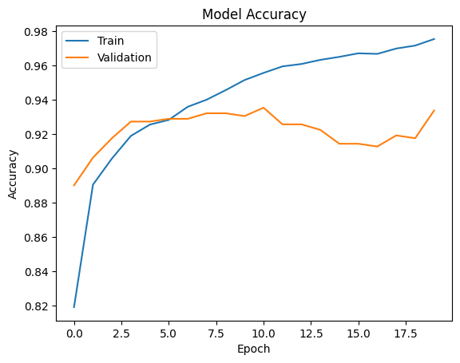

```python
plt.plot(history_1.history['accuracy']) #Complete the code to plot the train metrics
plt.plot(history_1.history['val_accuracy']) #Complete the code to plot the validation data metrics
plt.title('Model Accuracy') #Complete the code to define the title for the plot
plt.ylabel('Accuracy') #Complete the code to define the label for the y-axis
plt.xlabel('Epoch') #Complete the code to define the label for the x-axis
plt.legend(['Train', 'Validation'], loc='upper left')
plt.show()
```

```python
model_1_train_perf = model_performance_classification(model_1, X_train_normalized,y_train)

print("Train performance metrics")
print(model_1_train_perf)
```

```
91/91 ━━━━━━━━━━━━━━━━━━━━ 1s 4ms/step
Train performance metrics
   Accuracy    Recall  Precision  F1 Score
0  0.977832  0.977832   0.977832  0.977832
```

```
91/91 ━━━━━━━━━━━━━━━━━━━━ 0s 3ms/step
```

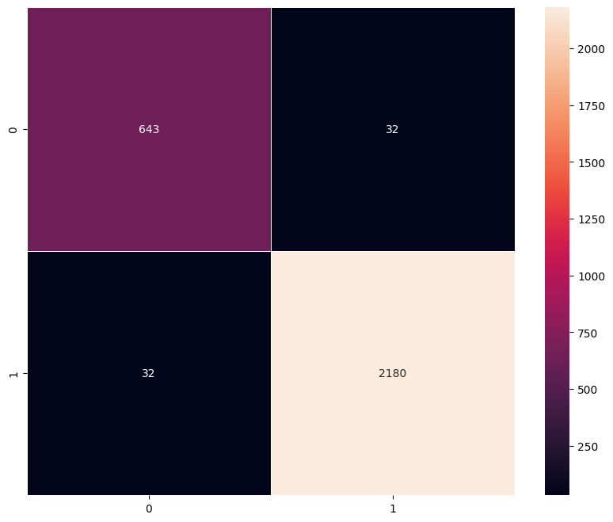

```python
plot_confusion_matrix(model_1,X_train_normalized,y_train)
```

```python
model_1_valid_perf = model_performance_classification(model_1, X_val_normalized,y_val)

print("Validation performance metrics")
print(model_1_valid_perf)
```

```
20/20 ━━━━━━━━━━━━━━━━━━━━ 0s 5ms/step
Validation performance metrics
   Accuracy    Recall  Precision  F1 Score
0  0.933764  0.933764   0.933764  0.933764
```

```
20/20 ━━━━━━━━━━━━━━━━━━━━ 0s 4ms/step
```

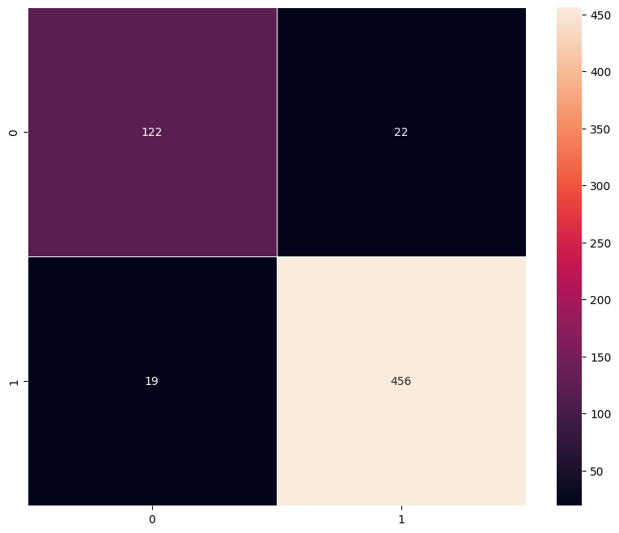

```python
plot_confusion_matrix(model_1,X_val_normalized,y_val)
```

### Visualizing the predictions

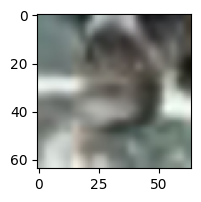

```
1/1 ━━━━━━━━━━━━━━━━━━━━ 0s 64ms/step
Predicted Label: 1
True Label: label    0
Name: 840, dtype: int64
```

```
1/1 ━━━━━━━━━━━━━━━━━━━━ 0s 59ms/step
Predicted Label: 1
True Label: label    1
Name: 1133, dtype: int64
```

```python
# For index 12
plt.figure(figsize=(2,2))
plt.imshow(X_val[12])
plt.show()
prediction = model_1.predict(X_val_normalized[12].reshape(1,64,64,3))
predicted_label = prediction[0][0]>0.5  # Extract the predicted class label
print('Predicted Label:', 1 if predicted_label else 0)
# Fix indexing issue in y_val
true_label = y_val.iloc[12]
print('True Label:', true_label)

# For index 33
plt.figure(figsize=(2,2))
plt.imshow(X_val[33])
plt.show()
prediction = model_1.predict(X_val_normalized[33].reshape(1,64,64,3))
predicted_label = prediction[0][0]>0.5  # Extract the predicted class label
print('Predicted Label:', 1 if predicted_label else 0)
# Fix indexing issue in y_val
true_label = y_val.iloc[33]
print('True Label:', true_label)
```

## Model 2: Transfer Learning with VGG-16 (Base)

I will be loading a pre-built architecture - VGG16, which was trained on the ImageNet dataset

For training VGG16, we will directly use the convolutional and pooling layers and freeze their weights i.e. no training will be done on them.

For classification, we will add a Flatten and a single dense layer (output).

```python
vgg_model = VGG16(weights='imagenet',include_top=False,input_shape=(64,64,3)) #Complete the code to define the shape of the image
vgg_model.summary()
```

```
Model: "vgg16"
```

```
┏━━━━━━━━━━━━━━━━━━━━━━━━━━━━━━━━━┳━━━━━━━━━━━━━━━━━━━━━━━━┳━━━━━━━━━━━━━━━┓
┃ Layer (type)                    ┃ Output Shape           ┃       Param # ┃
┡━━━━━━━━━━━━━━━━━━━━━━━━━━━━━━━━━╇━━━━━━━━━━━━━━━━━━━━━━━━╇━━━━━━━━━━━━━━━┩
│ input_layer_9 (InputLayer)      │ (None, 64, 64, 3)      │             0 │
├─────────────────────────────────┼────────────────────────┼───────────────┤
│ block1_conv1 (Conv2D)           │ (None, 64, 64, 64)     │         1,792 │
├─────────────────────────────────┼────────────────────────┼───────────────┤
│ block1_conv2 (Conv2D)           │ (None, 64, 64, 64)     │        36,928 │
├─────────────────────────────────┼────────────────────────┼───────────────┤
│ block1_pool (MaxPooling2D)      │ (None, 32, 32, 64)     │             0 │
├─────────────────────────────────┼────────────────────────┼───────────────┤
│ block2_conv1 (Conv2D)           │ (None, 32, 32, 128)    │        73,856 │
├─────────────────────────────────┼────────────────────────┼───────────────┤
│ block2_conv2 (Conv2D)           │ (None, 32, 32, 128)    │       147,584 │
├─────────────────────────────────┼────────────────────────┼───────────────┤
│ block2_pool (MaxPooling2D)      │ (None, 16, 16, 128)    │             0 │
├─────────────────────────────────┼────────────────────────┼───────────────┤
│ block3_conv1 (Conv2D)           │ (None, 16, 16, 256)    │       295,168 │
├─────────────────────────────────┼────────────────────────┼───────────────┤
│ block3_conv2 (Conv2D)           │ (None, 16, 16, 256)    │       590,080 │
├─────────────────────────────────┼────────────────────────┼───────────────┤
│ block3_conv3 (Conv2D)           │ (None, 16, 16, 256)    │       590,080 │
├─────────────────────────────────┼────────────────────────┼───────────────┤
│ block3_pool (MaxPooling2D)      │ (None, 8, 8, 256)      │             0 │
├─────────────────────────────────┼────────────────────────┼───────────────┤
│ block4_conv1 (Conv2D)           │ (None, 8, 8, 512)      │     1,180,160 │
├─────────────────────────────────┼────────────────────────┼───────────────┤
│ block4_conv2 (Conv2D)           │ (None, 8, 8, 512)      │     2,359,808 │
├─────────────────────────────────┼────────────────────────┼───────────────┤
│ block4_conv3 (Conv2D)           │ (None, 8, 8, 512)      │     2,359,808 │
├─────────────────────────────────┼────────────────────────┼───────────────┤
│ block4_pool (MaxPooling2D)      │ (None, 4, 4, 512)      │             0 │
├─────────────────────────────────┼────────────────────────┼───────────────┤
│ block5_conv1 (Conv2D)           │ (None, 4, 4, 512)      │     2,359,808 │
├─────────────────────────────────┼────────────────────────┼───────────────┤
│ block5_conv2 (Conv2D)           │ (None, 4, 4, 512)      │     2,359,808 │
├─────────────────────────────────┼────────────────────────┼───────────────┤
│ block5_conv3 (Conv2D)           │ (None, 4, 4, 512)      │     2,359,808 │
├─────────────────────────────────┼────────────────────────┼───────────────┤
│ block5_pool (MaxPooling2D)      │ (None, 2, 2, 512)      │             0 │
└─────────────────────────────────┴────────────────────────┴───────────────┘
```

```
 Total params: 14,714,688 (56.13 MB)
```

```
 Trainable params: 14,714,688 (56.13 MB)
```

```
 Non-trainable params: 0 (0.00 B)
```

```python
# Making all the layers of the VGG model non-trainable. i.e. freezing them
for layer in vgg_model.layers:
    layer.trainable = False
```

```python
model_2 = Sequential()

# Adding the convolutional part of the VGG16 model from above
model_2.add(vgg_model)

# Flattening the output of the VGG16 model because it is from a convolutional layer
model_2.add(Flatten())

# Adding a dense output layer for binary classification
model_2.add(Dense(1, activation='sigmoid'))
```

```python
opt=Adam()
# Compile model for binary classification
model_2.compile(optimizer=opt, loss='binary_crossentropy', metrics=['accuracy', 'precision'])
```

```python
# Generating the summary of the model
model_2.summary()
```

```
Model: "sequential_7"
```

```
┏━━━━━━━━━━━━━━━━━━━━━━━━━━━━━━━━━┳━━━━━━━━━━━━━━━━━━━━━━━━┳━━━━━━━━━━━━━━━┓
┃ Layer (type)                    ┃ Output Shape           ┃       Param # ┃
┡━━━━━━━━━━━━━━━━━━━━━━━━━━━━━━━━━╇━━━━━━━━━━━━━━━━━━━━━━━━╇━━━━━━━━━━━━━━━┩
│ vgg16 (Functional)              │ (None, 2, 2, 512)      │    14,714,688 │
├─────────────────────────────────┼────────────────────────┼───────────────┤
│ flatten_7 (Flatten)             │ (None, 2048)           │             0 │
├─────────────────────────────────┼────────────────────────┼───────────────┤
│ dense_12 (Dense)                │ (None, 1)              │         2,049 │
└─────────────────────────────────┴────────────────────────┴───────────────┘
```

```
 Total params: 14,716,737 (56.14 MB)
```

```
 Trainable params: 2,049 (8.00 KB)
```

```
 Non-trainable params: 14,714,688 (56.13 MB)
```

```python
train_datagen = ImageDataGenerator()
```

```python
# Epochs
epochs = 20
# Batch size
batch_size = 128

history_vgg16 = model_1.fit(train_datagen.flow(X_train_normalized,y_train_encoded,
                                       batch_size=batch_size,
                                       seed=42,
                                       shuffle=False),
                    epochs=epochs,
                    steps_per_epoch=X_train_normalized.shape[0] // batch_size,
                    validation_data=(X_val_normalized,y_val_encoded),
                    verbose=1)
```

```
22/22 ━━━━━━━━━━━━━━━━━━━━ 2s 87ms/step - accuracy: 0.8851 - loss: 0.2853 - precision: 0.8882 - val_accuracy: 0.8691 - val_loss: 0.3043 - val_precision: 0.8924
22/22 ━━━━━━━━━━━━━━━━━━━━ 0s 21ms/step - accuracy: 0.8828 - loss: 0.3080 - precision: 0.9184 - val_accuracy: 0.8659 - val_loss: 0.3036 - val_precision: 0.8889
22/22 ━━━━━━━━━━━━━━━━━━━━ 2s 95ms/step - accuracy: 0.8840 - loss: 0.2769 - precision: 0.8885 - val_accuracy: 0.8659 - val_loss: 0.2986 - val_precision: 0.8904
22/22 ━━━━━━━━━━━━━━━━━━━━ 1s 21ms/step - accuracy: 0.8672 - loss: 0.3173 - precision: 0.8679 - val_accuracy: 0.8708 - val_loss: 0.2996 - val_precision: 0.8974
22/22 ━━━━━━━━━━━━━━━━━━━━ 4s 84ms/step - accuracy: 0.8938 - loss: 0.2723 - precision: 0.9000 - val_accuracy: 0.8691 - val_loss: 0.2938 - val_precision: 0.8956
22/22 ━━━━━━━━━━━━━━━━━━━━ 0s 20ms/step - accuracy: 0.8516 - loss: 0.2854 - precision: 0.8788 - val_accuracy: 0.8691 - val_loss: 0.2937 - val_precision: 0.8956
22/22 ━━━━━━━━━━━━━━━━━━━━ 2s 86ms/step - accuracy: 0.8978 - loss: 0.2665 - precision: 0.9037 - val_accuracy: 0.8611 - val_loss: 0.2902 - val_precision: 0.8806
22/22 ━━━━━━━━━━━━━━━━━━━━ 0s 21ms/step - accuracy: 0.8750 - loss: 0.2533 - precision: 0.8762 - val_accuracy: 0.8627 - val_loss: 0.2899 - val_precision: 0.8824
22/22 ━━━━━━━━━━━━━━━━━━━━ 2s 86ms/step - accuracy: 0.8985 - loss: 0.2610 - precision: 0.9041 - val_accuracy: 0.8740 - val_loss: 0.2870 - val_precision: 0.9010
22/22 ━━━━━━━━━━━━━━━━━━━━ 0s 20ms/step - accuracy: 0.8906 - loss: 0.2460 - precision: 0.9091 - val_accuracy: 0.8740 - val_loss: 0.2867 - val_precision: 0.9010
22/22 ━━━━━━━━━━━━━━━━━━━━ 2s 87ms/step - accuracy: 0.9007 - loss: 0.2573 - precision: 0.9081 - val_accuracy: 0.8756 - val_loss: 0.2818 - val_precision: 0.9028
22/22 ━━━━━━━━━━━━━━━━━━━━ 1s 22ms/step - accuracy: 0.9141 - loss: 0.2103 - precision: 0.9375 - val_accuracy: 0.8724 - val_loss: 0.2816 - val_precision: 0.8976
22/22 ━━━━━━━━━━━━━━━━━━━━ 2s 98ms/step - accuracy: 0.9018 - loss: 0.2509 - precision: 0.9079 - val_accuracy: 0.8708 - val_loss: 0.2801 - val_precision: 0.8911
22/22 ━━━━━━━━━━━━━━━━━━━━ 1s 22ms/step - accuracy: 0.9062 - loss: 0.2570 - precision: 0.9057 - val_accuracy: 0.8708 - val_loss: 0.2799 - val_precision: 0.8911
22/22 ━━━━━━━━━━━━━━━━━━━━ 2s 87ms/step - accuracy: 0.9077 - loss: 0.2472 - precision: 0.9141 - val_accuracy: 0.8756 - val_loss: 0.2765 - val_precision: 0.8964
22/22 ━━━━━━━━━━━━━━━━━━━━ 0s 20ms/step - accuracy: 0.8732 - loss: 0.2552 - precision: 0.8548 - val_accuracy: 0.8805 - val_loss: 0.2762 - val_precision: 0.9034
22/22 ━━━━━━━━━━━━━━━━━━━━ 2s 85ms/step - accuracy: 0.9116 - loss: 0.2400 - precision: 0.9196 - val_accuracy: 0.8805 - val_loss: 0.2747 - val_precision: 0.9051
22/22 ━━━━━━━━━━━━━━━━━━━━ 0s 20ms/step - accuracy: 0.8750 - loss: 0.2819 - precision: 0.8899 - val_accuracy: 0.8772 - val_loss: 0.2744 - val_precision: 0.9014
22/22 ━━━━━━━━━━━━━━━━━━━━ 2s 84ms/step - accuracy: 0.9097 - loss: 0.2404 - precision: 0.9161 - val_accuracy: 0.8805 - val_loss: 0.2722 - val_precision: 0.9051
22/22 ━━━━━━━━━━━━━━━━━━━━ 0s 21ms/step - accuracy: 0.9453 - loss: 0.1871 - precision: 0.9636 - val_accuracy: 0.8805 - val_loss: 0.2720 - val_precision: 0.9051
```

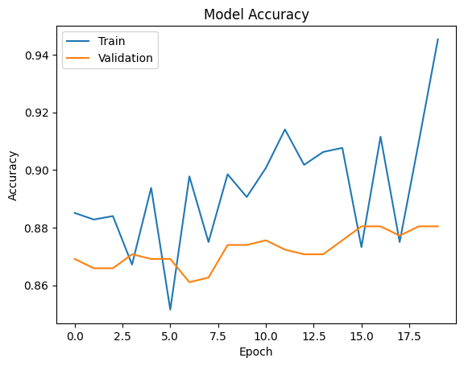

```python
plt.plot(history_vgg16.history['accuracy'])
plt.plot(history_vgg16.history['val_accuracy'])
plt.title('Model Accuracy')
plt.ylabel('Accuracy')
plt.xlabel('Epoch')
plt.legend(['Train', 'Validation'], loc='upper left')
plt.show()
```

```python
model_2_train_perf = model_performance_classification(model_2, X_train_normalized,y_train_encoded)

print("Train performance metrics")
print(model_2_train_perf)
```

```
91/91 ━━━━━━━━━━━━━━━━━━━━ 2s 21ms/step
Train performance metrics
   Accuracy    Recall  Precision  F1 Score
0  0.413232  0.413232   0.413232  0.413232
```

```
91/91 ━━━━━━━━━━━━━━━━━━━━ 2s 19ms/step
```

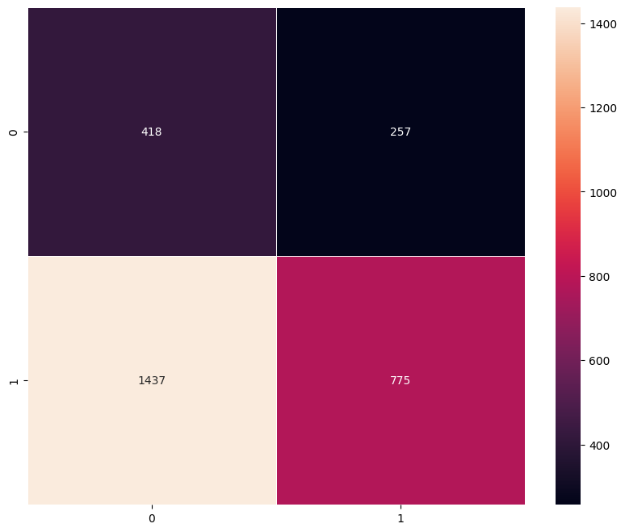

```python
plot_confusion_matrix(model_2,X_train_normalized,y_train_encoded)
```

```python
model_2_valid_perf = model_performance_classification(model_2, X_val_normalized,y_val_encoded)

print("Validation performance metrics")
print(model_2_valid_perf)
```

```
20/20 ━━━━━━━━━━━━━━━━━━━━ 0s 19ms/step
Validation performance metrics
   Accuracy    Recall  Precision  F1 Score
0  0.420032  0.420032   0.420032  0.420032
```

```
20/20 ━━━━━━━━━━━━━━━━━━━━ 0s 20ms/step
```

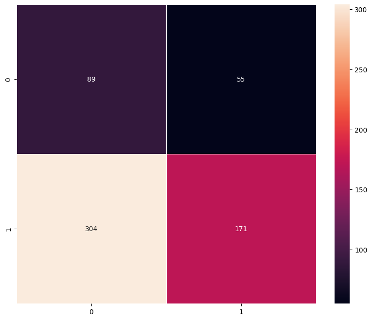

```python
plot_confusion_matrix(model_2,X_val_normalized,y_val_encoded)
```

### Visualizing the predictions

```
1/1 ━━━━━━━━━━━━━━━━━━━━ 0s 66ms/step
Predicted Label [1]
True Label 1
```

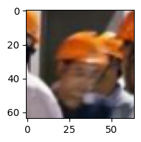

```
1/1 ━━━━━━━━━━━━━━━━━━━━ 0s 65ms/step
Predicted Label [0]
True Label 1
```

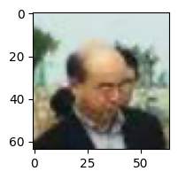

```
1/1 ━━━━━━━━━━━━━━━━━━━━ 0s 47ms/step
Predicted Label [0]
True Label 0
```

```python
# Visualizing the predicted and correct label of images from test data
plt.figure(figsize=(2,2))
plt.imshow(X_val[2])
plt.show()
print('Predicted Label', enc.inverse_transform(model_1.predict((X_val_normalized[2].reshape(1,64,64,3)))))   # reshaping the input image as we are only trying to predict using a single image
print('True Label', enc.inverse_transform(y_val_encoded)[2])                                               # using inverse_transform() to get the output label from the output vector

plt.figure(figsize=(2,2))
plt.imshow(X_val[10])
plt.show()
print('Predicted Label', enc.inverse_transform(model_1.predict((X_val_normalized[10].reshape(1,64,64,3)))))  # reshaping the input image as we are only trying to predict using a single image
print('True Label', enc.inverse_transform(y_val_encoded)[10])                                              # using inverse_transform() to get the output label from the output vector

plt.figure(figsize=(2,2))
plt.imshow(X_val[23])
plt.show()
print('Predicted Label', enc.inverse_transform(model_1.predict((X_val_normalized[23].reshape(1,64,64,3)))))  # reshaping the input image as we are only trying to predict using a single image
print('True Label', enc.inverse_transform(y_val_encoded)[23])
```

## Model 3: Transfer Learning with VGG-16 (Base + FFNN)

We will directly use the convolutional and pooling layers and freeze their weights i.e. no training will be done on them. For classification, **we will add a Flatten layer and a Feed Forward Neural Network**.

```python
model_3 = Sequential()

# Adding the convolutional part of the VGG16 model from above
model_3.add(vgg_model)

# Flattening the output of the VGG16 model because it is from a convolutional layer
model_3.add(Flatten())

#Adding the Feed Forward neural network
model_3.add(Dense(256,activation='relu'))
model_3.add(Dropout(rate=0.4))
model_3.add(Dense(32,activation='relu'))

# Adding a dense output layer for binary classification
model_3.add(Dense(1, activation='sigmoid'))
```

```python
opt = Adam()
```

```python
# Compile model for binary classification
model_3.compile(optimizer=opt, loss='binary_crossentropy', metrics=['accuracy', 'precision'])
```

```python
# Generating the summary of the model
model_3.summary()
```

```
Model: "sequential_11"
```

```
┏━━━━━━━━━━━━━━━━━━━━━━━━━━━━━━━━━┳━━━━━━━━━━━━━━━━━━━━━━━━┳━━━━━━━━━━━━━━━┓
┃ Layer (type)                    ┃ Output Shape           ┃       Param # ┃
┡━━━━━━━━━━━━━━━━━━━━━━━━━━━━━━━━━╇━━━━━━━━━━━━━━━━━━━━━━━━╇━━━━━━━━━━━━━━━┩
│ vgg16 (Functional)              │ (None, 2, 2, 512)      │    14,714,688 │
├─────────────────────────────────┼────────────────────────┼───────────────┤
│ flatten_11 (Flatten)            │ (None, 2048)           │             0 │
├─────────────────────────────────┼────────────────────────┼───────────────┤
│ dense_22 (Dense)                │ (None, 256)            │       524,544 │
├─────────────────────────────────┼────────────────────────┼───────────────┤
│ dropout_4 (Dropout)             │ (None, 256)            │             0 │
├─────────────────────────────────┼────────────────────────┼───────────────┤
│ dense_23 (Dense)                │ (None, 32)             │         8,224 │
├─────────────────────────────────┼────────────────────────┼───────────────┤
│ dense_24 (Dense)                │ (None, 1)              │            33 │
└─────────────────────────────────┴────────────────────────┴───────────────┘
```

```
 Total params: 15,247,489 (58.16 MB)
```

```
 Trainable params: 532,801 (2.03 MB)
```

```
 Non-trainable params: 14,714,688 (56.13 MB)
```

```python
history_vgg16 = model_3.fit(train_datagen.flow(X_train_normalized,y_train_encoded,
                                       batch_size=batch_size,
                                       seed=42,
                                       shuffle=False),
                    epochs=epochs,
                    steps_per_epoch=X_train_normalized.shape[0] // batch_size,
                    validation_data=(X_val_normalized,y_val_encoded),
                    verbose=1)
```

```
22/22 ━━━━━━━━━━━━━━━━━━━━ 6s 105ms/step - accuracy: 0.7789 - loss: 0.4919 - precision: 0.7910 - val_accuracy: 0.8191 - val_loss: 0.3718 - val_precision: 0.8355
22/22 ━━━━━━━━━━━━━━━━━━━━ 0s 20ms/step - accuracy: 0.7891 - loss: 0.4310 - precision: 0.8036 - val_accuracy: 0.8191 - val_loss: 0.3656 - val_precision: 0.8367
22/22 ━━━━━━━━━━━━━━━━━━━━ 2s 86ms/step - accuracy: 0.8525 - loss: 0.3471 - precision: 0.8713 - val_accuracy: 0.8530 - val_loss: 0.3181 - val_precision: 0.9120
22/22 ━━━━━━━━━━━━━━━━━━━━ 0s 20ms/step - accuracy: 0.8359 - loss: 0.3465 - precision: 0.9130 - val_accuracy: 0.8595 - val_loss: 0.3069 - val_precision: 0.8975
22/22 ━━━━━━━━━━━━━━━━━━━━ 2s 88ms/step - accuracy: 0.8702 - loss: 0.2967 - precision: 0.8911 - val_accuracy: 0.8821 - val_loss: 0.2717 - val_precision: 0.9153
22/22 ━━━━━━━━━━━━━━━━━━━━ 1s 21ms/step - accuracy: 0.9219 - loss: 0.2513 - precision: 0.9459 - val_accuracy: 0.8821 - val_loss: 0.2745 - val_precision: 0.9223
22/22 ━━━━━━━━━━━━━━━━━━━━ 2s 88ms/step - accuracy: 0.8866 - loss: 0.2595 - precision: 0.9096 - val_accuracy: 0.8724 - val_loss: 0.2624 - val_precision: 0.8976
22/22 ━━━━━━━━━━━━━━━━━━━━ 0s 20ms/step - accuracy: 0.8906 - loss: 0.2508 - precision: 0.9184 - val_accuracy: 0.8724 - val_loss: 0.2610 - val_precision: 0.8976
22/22 ━━━━━━━━━━━━━━━━━━━━ 2s 91ms/step - accuracy: 0.9043 - loss: 0.2290 - precision: 0.9236 - val_accuracy: 0.8853 - val_loss: 0.2543 - val_precision: 0.9191
22/22 ━━━━━━━━━━━━━━━━━━━━ 1s 22ms/step - accuracy: 0.9219 - loss: 0.2279 - precision: 0.9579 - val_accuracy: 0.8837 - val_loss: 0.2610 - val_precision: 0.9278
22/22 ━━━━━━━━━━━━━━━━━━━━ 2s 92ms/step - accuracy: 0.9155 - loss: 0.2142 - precision: 0.9400 - val_accuracy: 0.8869 - val_loss: 0.2539 - val_precision: 0.9158
22/22 ━━━━━━━━━━━━━━━━━━━━ 0s 20ms/step - accuracy: 0.8984 - loss: 0.2435 - precision: 0.9151 - val_accuracy: 0.8724 - val_loss: 0.2663 - val_precision: 0.8882
22/22 ━━━━━━━━━━━━━━━━━━━━ 2s 90ms/step - accuracy: 0.9177 - loss: 0.1942 - precision: 0.9360 - val_accuracy: 0.8966 - val_loss: 0.2653 - val_precision: 0.9419
22/22 ━━━━━━━━━━━━━━━━━━━━ 0s 20ms/step - accuracy: 0.8906 - loss: 0.2043 - precision: 0.9592 - val_accuracy: 0.8805 - val_loss: 0.2619 - val_precision: 0.9018
22/22 ━━━━━━━━━━━━━━━━━━━━ 2s 87ms/step - accuracy: 0.9275 - loss: 0.1799 - precision: 0.9411 - val_accuracy: 0.8918 - val_loss: 0.2496 - val_precision: 0.9198
22/22 ━━━━━━━━━━━━━━━━━━━━ 0s 20ms/step - accuracy: 0.9219 - loss: 0.1862 - precision: 0.9375 - val_accuracy: 0.8966 - val_loss: 0.2482 - val_precision: 0.9272
22/22 ━━━━━━━━━━━━━━━━━━━━ 2s 86ms/step - accuracy: 0.9402 - loss: 0.1517 - precision: 0.9551 - val_accuracy: 0.8982 - val_loss: 0.2571 - val_precision: 0.9402
22/22 ━━━━━━━━━━━━━━━━━━━━ 0s 20ms/step - accuracy: 0.9297 - loss: 0.1606 - precision: 0.9510 - val_accuracy: 0.8982 - val_loss: 0.2612 - val_precision: 0.9440
22/22 ━━━━━━━━━━━━━━━━━━━━ 2s 84ms/step - accuracy: 0.9453 - loss: 0.1401 - precision: 0.9599 - val_accuracy: 0.8772 - val_loss: 0.2697 - val_precision: 0.8998
22/22 ━━━━━━━━━━━━━━━━━━━━ 0s 21ms/step - accuracy: 0.9609 - loss: 0.0949 - precision: 0.9815 - val_accuracy: 0.8885 - val_loss: 0.2658 - val_precision: 0.9143
```

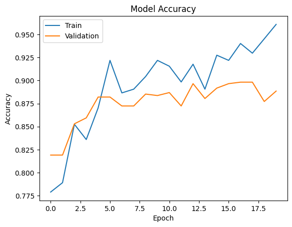

```python
plt.plot(history_vgg16.history['accuracy'])
plt.plot(history_vgg16.history['val_accuracy'])
plt.title('Model Accuracy')
plt.ylabel('Accuracy')
plt.xlabel('Epoch')
plt.legend(['Train', 'Validation'], loc='upper left')
plt.show()
```

```python
model_3_train_perf = model_performance_classification(model_3, X_train_normalized,y_train_encoded)

print("Train performance metrics")
print(model_3_train_perf)
```

```
91/91 ━━━━━━━━━━━━━━━━━━━━ 2s 19ms/step
Train performance metrics
   Accuracy    Recall  Precision  F1 Score
0  0.959474  0.959474   0.959474  0.959474
```

```
91/91 ━━━━━━━━━━━━━━━━━━━━ 2s 19ms/step
```

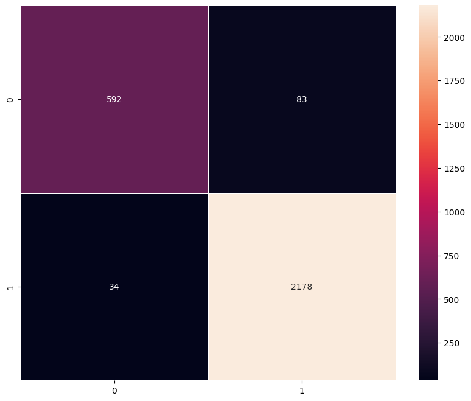

```python
plot_confusion_matrix(model_3,X_train_normalized,y_train_encoded)
```

```python
model_3_valid_perf = model_performance_classification(model_3, X_val_normalized,y_val_encoded)

print("Validation performance metrics")
print(model_3_valid_perf)
```

```
20/20 ━━━━━━━━━━━━━━━━━━━━ 1s 24ms/step
Validation performance metrics
   Accuracy   Recall  Precision  F1 Score
0   0.88853  0.88853    0.88853   0.88853
```

```
20/20 ━━━━━━━━━━━━━━━━━━━━ 0s 22ms/step
```

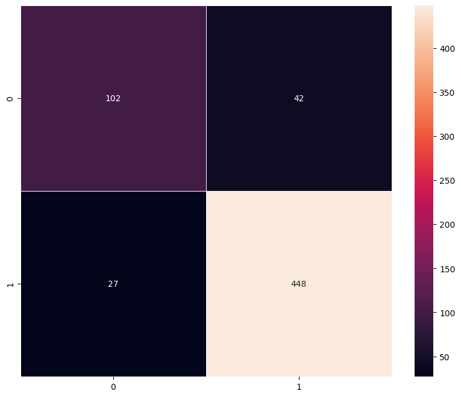

```python
plot_confusion_matrix(model_3,X_val_normalized,y_val_encoded)
```

The model has achieved approximately 96% accuracy on the training set and 88% accuracy on the validation set.

#### Visualizing the predictions

```
1/1 ━━━━━━━━━━━━━━━━━━━━ 0s 67ms/step
Predicted Label [1]
True Label 1
```

```
1/1 ━━━━━━━━━━━━━━━━━━━━ 0s 65ms/step
Predicted Label [0]
True Label 1
```

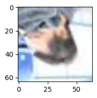

```
1/1 ━━━━━━━━━━━━━━━━━━━━ 0s 66ms/step
Predicted Label [1]
True Label 0
```

```python
# Visualizing the predicted and correct label of images from test data
plt.figure(figsize=(2,2))
plt.imshow(X_val[2])
plt.show()
print('Predicted Label', enc.inverse_transform(model_3.predict((X_val_normalized[2].reshape(1,64,64,3)))))   # reshaping the input image as we are only trying to predict using a single image
print('True Label', enc.inverse_transform(y_val_encoded)[2])                                               # using inverse_transform() to get the output label from the output vector

plt.figure(figsize=(2,2))
plt.imshow(X_val[33])
plt.show()
print('Predicted Label', enc.inverse_transform(model_3.predict((X_val_normalized[33].reshape(1,64,64,3)))))  # reshaping the input image as we are only trying to predict using a single image
print('True Label', enc.inverse_transform(y_val_encoded)[33])                                              # using inverse_transform() to get the output label from the output vector

plt.figure(figsize=(2,2))
plt.imshow(X_val[36])
plt.show()
print('Predicted Label', enc.inverse_transform(model_3.predict((X_val_normalized[36].reshape(1,64,64,3)))))  # reshaping the input image as we are only trying to predict using a single image
print('True Label', enc.inverse_transform(y_val_encoded)[36])
```

## Model 4: Transfer Learning with VGG-16 (Base + FFNN + Data Augmentation)

- In most of the real-world case studies, it is challenging to acquire a large number of images and then train CNNs.
- To overcome this problem, one approach we might consider is **Data Augmentation**.
- CNNs have the property of **translational invariance**, which means they can recognise an object even if its appearance shifts translationally in some way. - Taking this attribute into account, we can augment the images using the techniques listed below
  - Horizontal Flip (should be set to True/False)
  - Vertical Flip (should be set to True/False)
  - Height Shift (should be between 0 and 1)
  - Width Shift (should be between 0 and 1)
  - Rotation (should be between 0 and 180)
  - Shear (should be between 0 and 1)
  - Zoom (should be between 0 and 1) etc.

Remember, **data augmentation should not be used in the validation/test data set**.

```python
model_4 = Sequential()

# Adding the convolutional part of the VGG16 model from above
model_4.add(vgg_model)

# Flattening the output of the VGG16 model because it is from a convolutional layer
model_4.add(Flatten())

#Adding the Feed Forward neural network
model_4.add(Dense(256,activation='relu'))
model_4.add(Dropout(rate=0.4))
model_4.add(Dense(32,activation='relu'))

# Adding a dense output layer
model_4.add(Dense(1, activation='sigmoid'))
```

```python
opt=Adam()

# Compile model for binary classification
model_4.compile(optimizer=opt, loss='binary_crossentropy', metrics=['accuracy', 'precision'])
```

```python
# Generating the summary of the model
model_4.summary()
```

```
Model: "sequential_12"
```

```
┏━━━━━━━━━━━━━━━━━━━━━━━━━━━━━━━━━┳━━━━━━━━━━━━━━━━━━━━━━━━┳━━━━━━━━━━━━━━━┓
┃ Layer (type)                    ┃ Output Shape           ┃       Param # ┃
┡━━━━━━━━━━━━━━━━━━━━━━━━━━━━━━━━━╇━━━━━━━━━━━━━━━━━━━━━━━━╇━━━━━━━━━━━━━━━┩
│ vgg16 (Functional)              │ (None, 2, 2, 512)      │    14,714,688 │
├─────────────────────────────────┼────────────────────────┼───────────────┤
│ flatten_12 (Flatten)            │ (None, 2048)           │             0 │
├─────────────────────────────────┼────────────────────────┼───────────────┤
│ dense_25 (Dense)                │ (None, 256)            │       524,544 │
├─────────────────────────────────┼────────────────────────┼───────────────┤
│ dropout_5 (Dropout)             │ (None, 256)            │             0 │
├─────────────────────────────────┼────────────────────────┼───────────────┤
│ dense_26 (Dense)                │ (None, 32)             │         8,224 │
├─────────────────────────────────┼────────────────────────┼───────────────┤
│ dense_27 (Dense)                │ (None, 1)              │            33 │
└─────────────────────────────────┴────────────────────────┴───────────────┘
```

```
 Total params: 15,247,489 (58.16 MB)
```

```
 Trainable params: 532,801 (2.03 MB)
```

```
 Non-trainable params: 14,714,688 (56.13 MB)
```

```python
# Applying data augmentation
train_datagen = ImageDataGenerator(
                              rotation_range=20,
                              fill_mode='nearest',
                              width_shift_range=0.2,
                              height_shift_range=0.2,
                              shear_range=0.3,
                              zoom_range=0.4
                              )
```

```python
history_vgg16 = model_4.fit(train_datagen.flow(X_train_normalized,y_train_encoded,
                                       batch_size=batch_size,
                                       seed=42,
                                       shuffle=False),
                    epochs=epochs,
                    steps_per_epoch=X_train_normalized.shape[0] // batch_size,
                    validation_data=(X_val_normalized,y_val_encoded),
                    verbose=1)
```

```
22/22 ━━━━━━━━━━━━━━━━━━━━ 8s 320ms/step - accuracy: 0.7738 - loss: 0.4840 - precision: 0.7913 - val_accuracy: 0.8288 - val_loss: 0.3703 - val_precision: 0.8727
22/22 ━━━━━━━━━━━━━━━━━━━━ 1s 20ms/step - accuracy: 0.9062 - loss: 0.3189 - precision: 0.9450 - val_accuracy: 0.8271 - val_loss: 0.3664 - val_precision: 0.8525
22/22 ━━━━━━━━━━━━━━━━━━━━ 5s 212ms/step - accuracy: 0.8195 - loss: 0.3845 - precision: 0.8485 - val_accuracy: 0.8449 - val_loss: 0.3286 - val_precision: 0.8752
22/22 ━━━━━━━━━━━━━━━━━━━━ 1s 20ms/step - accuracy: 0.8203 - loss: 0.3554 - precision: 0.8393 - val_accuracy: 0.8352 - val_loss: 0.3314 - val_precision: 0.8580
22/22 ━━━━━━━━━━━━━━━━━━━━ 6s 280ms/step - accuracy: 0.8249 - loss: 0.3628 - precision: 0.8531 - val_accuracy: 0.8627 - val_loss: 0.3025 - val_precision: 0.9029
22/22 ━━━━━━━━━━━━━━━━━━━━ 1s 20ms/step - accuracy: 0.8281 - loss: 0.3510 - precision: 0.8476 - val_accuracy: 0.8611 - val_loss: 0.3141 - val_precision: 0.9219
22/22 ━━━━━━━━━━━━━━━━━━━━ 5s 207ms/step - accuracy: 0.8427 - loss: 0.3497 - precision: 0.8740 - val_accuracy: 0.8691 - val_loss: 0.2996 - val_precision: 0.9301
22/22 ━━━━━━━━━━━━━━━━━━━━ 1s 20ms/step - accuracy: 0.8125 - loss: 0.3967 - precision: 0.8776 - val_accuracy: 0.8788 - val_loss: 0.2906 - val_precision: 0.9132
22/22 ━━━━━━━━━━━━━━━━━━━━ 5s 211ms/step - accuracy: 0.8586 - loss: 0.3288 - precision: 0.8819 - val_accuracy: 0.8724 - val_loss: 0.2833 - val_precision: 0.9091
22/22 ━━━━━━━━━━━━━━━━━━━━ 1s 21ms/step - accuracy: 0.8594 - loss: 0.3247 - precision: 0.8889 - val_accuracy: 0.8708 - val_loss: 0.2856 - val_precision: 0.9175
22/22 ━━━━━━━━━━━━━━━━━━━━ 6s 269ms/step - accuracy: 0.8612 - loss: 0.3172 - precision: 0.8918 - val_accuracy: 0.8756 - val_loss: 0.2765 - val_precision: 0.9012
22/22 ━━━━━━━━━━━━━━━━━━━━ 1s 19ms/step - accuracy: 0.8310 - loss: 0.3851 - precision: 0.8596 - val_accuracy: 0.8740 - val_loss: 0.2831 - val_precision: 0.8854
22/22 ━━━━━━━━━━━━━━━━━━━━ 5s 210ms/step - accuracy: 0.8605 - loss: 0.3145 - precision: 0.8880 - val_accuracy: 0.8885 - val_loss: 0.2662 - val_precision: 0.9229
22/22 ━━━━━━━━━━━━━━━━━━━━ 1s 19ms/step - accuracy: 0.8672 - loss: 0.2959 - precision: 0.8824 - val_accuracy: 0.8837 - val_loss: 0.2653 - val_precision: 0.9121
22/22 ━━━━━━━━━━━━━━━━━━━━ 6s 289ms/step - accuracy: 0.8615 - loss: 0.3153 - precision: 0.8920 - val_accuracy: 0.8772 - val_loss: 0.2687 - val_precision: 0.8998
22/22 ━━━━━━━━━━━━━━━━━━━━ 1s 19ms/step - accuracy: 0.8516 - loss: 0.3307 - precision: 0.8519 - val_accuracy: 0.8772 - val_loss: 0.2664 - val_precision: 0.9030
22/22 ━━━━━━━━━━━━━━━━━━━━ 8s 221ms/step - accuracy: 0.8587 - loss: 0.3202 - precision: 0.8919 - val_accuracy: 0.8853 - val_loss: 0.2632 - val_precision: 0.9226
22/22 ━━━━━━━━━━━━━━━━━━━━ 1s 19ms/step - accuracy: 0.8451 - loss: 0.3803 - precision: 0.8621 - val_accuracy: 0.8901 - val_loss: 0.2629 - val_precision: 0.9179
22/22 ━━━━━━━━━━━━━━━━━━━━ 6s 282ms/step - accuracy: 0.8652 - loss: 0.3011 - precision: 0.8928 - val_accuracy: 0.8885 - val_loss: 0.2666 - val_precision: 0.9319
22/22 ━━━━━━━━━━━━━━━━━━━━ 1s 19ms/step - accuracy: 0.8906 - loss: 0.2880 - precision: 0.9100 - val_accuracy: 0.8805 - val_loss: 0.2722 - val_precision: 0.9349
```

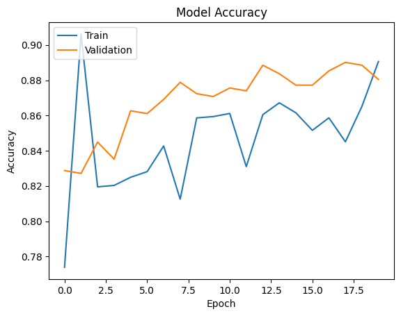

```python
plt.plot(history_vgg16.history['accuracy'])
plt.plot(history_vgg16.history['val_accuracy'])
plt.title('Model Accuracy')
plt.ylabel('Accuracy')
plt.xlabel('Epoch')
plt.legend(['Train', 'Validation'], loc='upper left')
plt.show()
```

```python
model_4_train_perf = model_performance_classification(model_4, X_train_normalized,y_train_encoded)

print("Train performance metrics")
print(model_4_train_perf)
```

```
91/91 ━━━━━━━━━━━━━━━━━━━━ 3s 29ms/step
Train performance metrics
   Accuracy   Recall  Precision  F1 Score
0   0.89574  0.89574    0.89574   0.89574
```

```
91/91 ━━━━━━━━━━━━━━━━━━━━ 2s 20ms/step
```

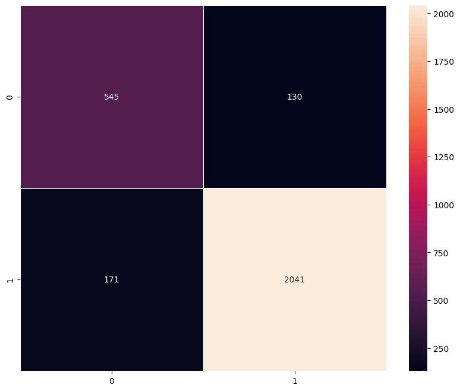

```python
plot_confusion_matrix(model_4,X_train_normalized,y_train_encoded)
```

```python
model_4_valid_perf = model_performance_classification(model_4, X_val_normalized,y_val_encoded)

print("Validation performance metrics")
print(model_4_valid_perf)
```

```
20/20 ━━━━━━━━━━━━━━━━━━━━ 0s 21ms/step
Validation performance metrics
   Accuracy    Recall  Precision  F1 Score
0  0.880452  0.880452   0.880452  0.880452
```

```
20/20 ━━━━━━━━━━━━━━━━━━━━ 1s 22ms/step
```

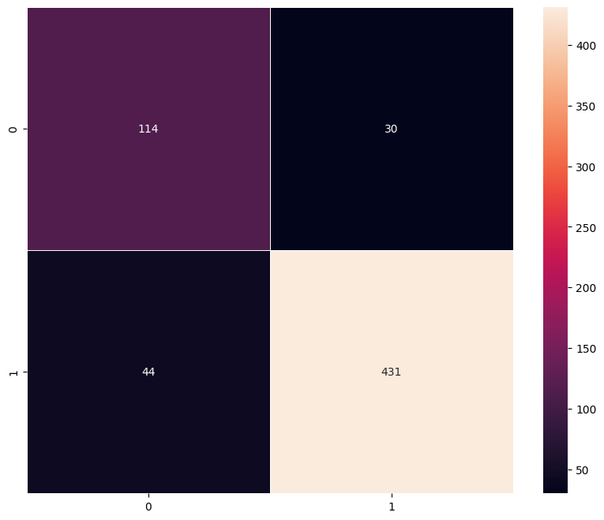

```python
plot_confusion_matrix(model_4,X_val_normalized,y_val_encoded)
```

The model has achieved approximately 89% accuracy on the training set and 88% accuracy on the validation set.

#### Visualizing the predictions

```
1/1 ━━━━━━━━━━━━━━━━━━━━ 0s 78ms/step
Predicted Label [1]
True Label 1
```

```
1/1 ━━━━━━━━━━━━━━━━━━━━ 0s 83ms/step
Predicted Label [0]
True Label 1
```

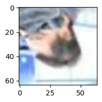

```
1/1 ━━━━━━━━━━━━━━━━━━━━ 0s 77ms/step
Predicted Label [0]
True Label 0
```

```python
# Visualizing the predicted and correct label of images from test data
plt.figure(figsize=(2,2))
plt.imshow(X_val[2])
plt.show()
print('Predicted Label', enc.inverse_transform(model_4.predict((X_val_normalized[2].reshape(1,64,64,3)))))   # reshaping the input image as we are only trying to predict using a single image
print('True Label', enc.inverse_transform(y_val_encoded)[2])                                               # using inverse_transform() to get the output label from the output vector

plt.figure(figsize=(2,2))
plt.imshow(X_val[33])
plt.show()
print('Predicted Label', enc.inverse_transform(model_4.predict((X_val_normalized[33].reshape(1,64,64,3)))))  # reshaping the input image as we are only trying to predict using a single image
print('True Label', enc.inverse_transform(y_val_encoded)[33])                                              # using inverse_transform() to get the output label from the output vector

plt.figure(figsize=(2,2))
plt.imshow(X_val[36])
plt.show()
print('Predicted Label', enc.inverse_transform(model_4.predict((X_val_normalized[36].reshape(1,64,64,3)))))  # reshaping the input image as we are only trying to predict using a single image
print('True Label', enc.inverse_transform(y_val_encoded)[36])
```

# **Model Performance Comparison and Final Model Selection**

```python
# training performance comparison

models_train_comp_df = pd.concat(
    [
        model_1_train_perf.T,
        model_2_train_perf.T,
        model_3_train_perf.T,
        model_4_train_perf.T,
    ],
    axis=1,
)
models_train_comp_df.columns = [
   "Simple Convolutional Neural Network (CNN)", "VGG-16 (Base)","VGG-16 (Base+FFNN)","VGG-16 (Base+FFNN+Data Aug)"
]
```

```python
models_valid_comp_df = pd.concat(
    [
        model_1_valid_perf.T,
        model_2_valid_perf.T,
        model_3_valid_perf.T,
        model_4_valid_perf.T

    ],
    axis=1,
)
models_valid_comp_df.columns = [
 "Simple Convolutional Neural Network (CNN)","VGG-16 (Base)","VGG-16 (Base+FFNN)","VGG-16 (Base+FFNN+Data Aug)"
]
```

```python
models_train_comp_df
```

[output not shown]

```python
models_valid_comp_df
```

[output not shown]

```python
models_train_comp_df - models_valid_comp_df
```

[output not shown]

## Test Performance

```python
model_3_test_perf = model_performance_classification(model_3, X_test_normalized,y_test) #Complete the code to pass the best model (Pass the variable corresponding to it. For example, model_1)
```

```
20/20 ━━━━━━━━━━━━━━━━━━━━ 1s 44ms/step
```

```
20/20 ━━━━━━━━━━━━━━━━━━━━ 1s 27ms/step
```

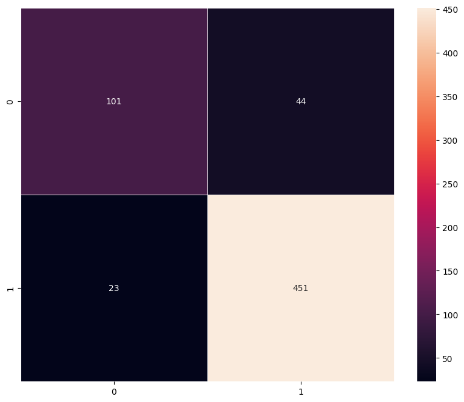

```python
plot_confusion_matrix(model_3, X_test_normalized,y_test_encoded)
```

# **Actionable Insights & Recommendations**

**Insights :**

1. Effectiveness of Transfer Learning

1. Need for a Custom Classification Head

1. Impact of Adding an FFNN Head

Introducing a custom Feed-Forward Neural Network (FFNN) head on top of VGG-16 led to a substantial improvement:

Training Accuracy: 95.95% Validation Accuracy: 88.85%

This confirms that tailoring the classifier to the problem is critical for performance.

1. Data Augmentation Trade-offs

Adding data augmentation slightly reduced validation accuracy:

Model 3 (No Augmentation): 88.85% Model 4 (With Augmentation): 88.05%

However, it reduced overfitting (smaller train-validation gap), suggesting:

Augmentation helped generalization But may have been too aggressive or unnecessary

1. Overfitting Observation Model 3 shows signs of overfitting (high train vs. validation gap) Model 4 improves generalization but at a minor cost in accuracy
2. Class Imbalance Impact

The dataset is imbalanced:

With Helmet: 3161 Without Helmet: 964

This can bias the model toward the majority class and affect recall for the minority class.

**Final Result:**

Model 3: VGG-16 + FFNN is the best-performing model:

Validation Accuracy: 0.8885 F1 Score: 0.8885 Test Accuracy: 0.8918

The close alignment between validation and test performance indicates strong generalization.

**Recommendations:**

1. Class Imbalance needs to be handled. Could Apply class weights, Try oversampling (SMOTE or duplication) Use Focal Loss to Improve detection of “Without Helmet” cases.
2. Could further analyze confusion matrix, Track precision/recall per class and focus on minimizing false negatives to emphasize on the safety.

Power Ahead!